# ЕГЭ 2018 Вариант 11 EGE 2018 Variant 11

Использованы материалы:

The list of used links and books:

[ЕГЭ 2018. Математика. Профильный уровень. 20 вариантов тестов. Тематическая рабочая тетрадь.](https://drive.google.com/file/d/0B8CJrELbJAyodmtvbV8xcEtZXzA/view)

[SymPy Tutorials](http://nbviewer.jupyter.org/url/www.inp.nsk.su/~grozin/python/sympy.ipynb)

[LaTeX Mathematics](https://en.wikibooks.org/wiki/LaTeX/Mathematics)

[Метод рационализации неравенств (логарифмы)](http://internat.msu.ru/wp-content/uploads/2015/11/Metod-ratsionalizatsii-neravenstv-1.pdf)

```python
%%html
<style>
@import url('https://fonts.googleapis.com/css?family=Roboto&effect=3d|scuffed-steel|static|canvas-print|');
a, h1 h2, h3, h4, div.text_cell_render {font-family: 'Roboto'; text-shadow: 4px 4px 4px #aaa;}

h2, h3, div.output_prompt, div.output_area pre {color: slategray;}
h1, h4, div.input_prompt {color: steelblue;}
a, div.output_subarea {color: darkblue;}

span {text-shadow: 4px 4px 4px #aaa;}

body, div.output_stderr pre{background-color: aliceblue;}
div.output_stderr {background-color: slategray;}
</style>
```

```python
import numpy
import pandas
import math

import matplotlib.pyplot as plt
import matplotlib.patches as pat
from mpl_toolkits.mplot3d import Axes3D
from mpl_toolkits.mplot3d.art3d import Poly3DCollection, Line3DCollection
import matplotlib
%matplotlib inline
```

```python
import sympy
from sympy import *
from sympy import init_printing
init_printing()
```

```python
answer_dictionary = dict()
```

## Часть 1 Part 1

[figure not shown]

### Задание 1 / Task 1

Держатели дисконтной карты книжного магазина получают при покупке скидку 2%. Книга стоит 250 рублей.

Сколько рублей заплатит держатель дисконтной карты за эту книгу?

Holders of discount cards of a bookstore get a 2% discount for buying. The book costs 250 rubles.

How many rubles will a holder of a discount card pay for this book?

Снижение цены на 2% соответствует уменьшению в 1 - 0,02 = 0,98 раза.

The price decrease of 2% corresponds to a decrease in 1 - 0.02 = 0.98 times.

$250 * (1 - 0.02) = 245$ (рублей / rubles)

### Ответ / Answer: 245

```python
answer_dictionary[1]=str(int(250 * (1 - 0.02)))
```

[figure not shown]

### Задание 2 / Task 2

На диаграмме показано число запросов со словом КИНО, сделанных на некотором поисковом сайте во все месяцы с января по сентябрь 2010 года. По горизонтали указываются месяцы, по вертикали - число запросов за данный месяц.

Определите по диаграмме наибольшее месячное число запросов со словом КИНО в указанный период.

The diagram shows the number of queries with the word КИНО, made on a search site in all months from January to September 2010. Months are indicated in the horizontal line, in the vertical - the number of requests for a given month.

Determine the largest monthly number of queries with the word КИНО for the specified period in the diagram.

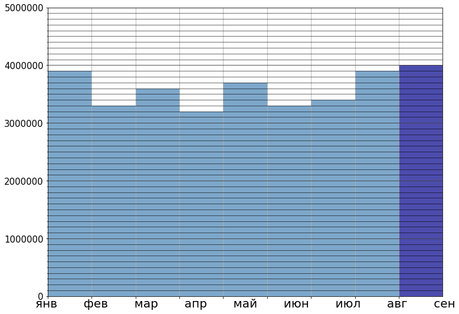

```python
months = ['янв','фев','мар','апр','май','июн','июл','авг','сен']
df=pandas.DataFrame({'months': months,
                     'queries': [3900000,3300000,3600000,3200000,3700000,
                                 3300000,3400000,3900000,4000000]})
fig,ax = plt.subplots()
df.plot(kind='bar', x='months', ax=ax,
        figsize=(12,9), grid=True,
        color='steelblue', alpha=0.7, align='edge', width=1)

ax.patches[8].set_facecolor('darkblue')

plt.xticks(visible=False)
plt.xlabel('       '.join(months), fontsize=20)

ax.set_yticklabels([0,1000000,2000000,3000000,4000000,5000000], fontsize=15)
ax.set_yticks(numpy.arange(0, 5000000, 100000), minor=True)
ax.grid(which='minor', alpha=0.7, color='black')

ax.legend().set_visible(False)

plt.xlim(0,9)
plt.ylim(0,5000000);
```

### Ответ / Answer: 4 000 000

```python
answer_dictionary[2]='4 000 000'
```

[figure not shown]

### Задание 3 / Task 3

На клетчатой бумаге с размером клетки 1 х 1 отмечены точки A, B и C.

On a graph paper with a cell size of 1 x 1, points A, B and C are marked.

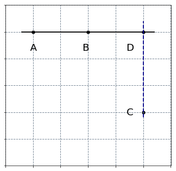

```python
plt.figure(figsize=(6,6))
plt.grid(c='slategray', ls='--', lw=1)

plt.scatter([1,3,5,5], [5,5,2,5], c='black')
plt.axhline(5, 0.1, 0.9, c='black', lw=2)
plt.axvline(5, 0.3, 0.9, c='darkblue', ls='--', lw=2)

plt.text(0.9,4.3,'A', fontsize=20)
plt.text(2.8,4.3,'B', fontsize=20)
plt.text(4.4,1.9,'C', fontsize=20)
plt.text(4.4,4.3,'D', fontsize=20)

plt.xlim(0,6)
plt.ylim(0,6)

plt.xticks(visible=False)
plt.yticks(visible=False);
```

### Ответ / Answer: 3

```python
answer_dictionary[3]=str(3)
```

[figure not shown]

### Задание 4 / Task 4

Из районного центра в деревню ежедневно ходит автобус. Вероятность того, что в понедельник в автобусе окажется меньше 17 пассажиров, равна 0,85. Вероятность того, что окажется меньше 11 пассажиров, равна 0,52.

Найдите вероятность того, что число пассажиров будет от 11 до 16.

A bus runs daily from the district center to the village. The probability that on Monday there will be less than 17 passengers on the bus is 0.85.

The probability that there will be less than 11 passengers is 0.52.

Find the probability that the number of passengers will be from 11 to 16.

$A = [0,11) \cup B = [11,16] \equiv C = [0;16]$

$p_A + p_B = p_C \implies p_B = 0.85 - 0.52 = 0.33$

### Ответ / Answer: 0.33

```python
answer_dictionary[4]=str(round(0.85-0.52,2))
```

[figure not shown]

### Задание 5 / Task 5

Найдите корень уравнения:

Find the root of the equation:

$\sqrt{x + 4} = 7$

### Ответ / Answer: 45

```python
%%latex
$\sqrt{x + 4} = 7 \iff
\begin {cases}
x + 4 \geq 0 \\
x + 4 = 49
\end {cases}
\iff x = 45$
```

$\sqrt{x + 4} = 7 \iff \begin {cases} x + 4 \geq 0 \\ x + 4 = 49 \end {cases} \iff x = 45$

```python
answer_dictionary[5]=str(7**2-4)
```

[figure not shown]

### Задание 6 / Task 6

В прямоугольном треугольнике высота, проведенная к гипотенузе, делит прямой угол на два угла, один из которых равен $56^o$.

Найдите меньший угол данного треугольника. Ответ дайте в градусах.

In a rectangular triangle, the height drawn to the hypotenuse divides the right angle into two angles, one of which is equal to $56^o$.

Find the smaller angle of this triangle. Give the answer in degrees.

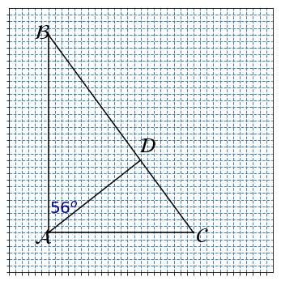

```python
f = plt.figure(figsize=(6,6))
ax = f.add_subplot(1, 1, 1, aspect=1)
ax.grid(c='steelblue', ls='--', lw=1)

ax.axhline(-7, 0.15, 0.7, c='black')
ax.axvline(-7, 0.15, 0.9, c='black')
ax.plot([-7,4], [8,-7], c='black')
ax.plot([-7,0], [-7,-1.5], c='black')

plt.text(-8.1,-7.7,r'$\mathcal{A}$', fontsize=25)
plt.text(-8.1,7.7,r'$\mathcal{B}$', fontsize=25)
plt.text(4.1,-7.7,r'$\mathcal{C}$', fontsize=25)
plt.text(-0.2,-0.9,r'$\mathcal{D}$', fontsize=25)
plt.text(-6.9,-5.5,r'$56^o$', fontsize=20, color='darkblue')

plt.xlim(-10,10)
plt.ylim(-10,10)
plt.xticks(numpy.arange(-10, 10, step=0.5), visible=False)
plt.yticks(numpy.arange(-10, 10, step=0.5), visible=False);
```

$\bigtriangleup ABD: AD \bot BD \implies \angle ABD = 90^o - \angle BAD = 90^o - 56^o = 34^o$

$\bigtriangleup ABC: BA \bot BC \implies \angle ACB = 90^o - \angle ABC = \angle BAD = 56^o$

### Ответ / Answer: 34

```python
answer_dictionary[6]=str(90-56)
```

[figure not shown]

### Задание 7 / Task 7

На рисунке изображены график функции $ \ y = f(x) \ $ и десять точек на оси абсцисс:

The figure shows the graph of the function $ \ y = f(x)\ $ and ten points on the abscissa:

$x_1, x_2, x_3, x_4, x_5, x_6, x_7, x_8, x_9, x_{10}$.

В скольких из этих точек производная функции $ \ f'(x) \ $ отрицательна?

In how many of these points is the derivative $ \ f'(x) \ $ negative?

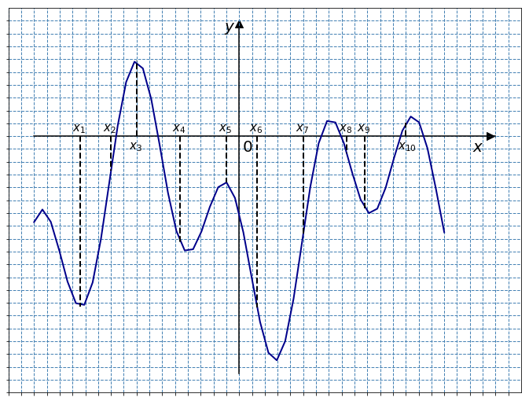

```python
f = plt.figure(figsize=(12,9))
ax = f.add_subplot(1, 1, 1, aspect=1)
ax.grid(c='steelblue', ls='--', lw=1)
ax.axhline(0, 0.05, 0.95, c='black')
ax.axvline(0, 0.05, 0.95, c='black')

def f(x,a=6,b=0.5,c=1.2,d=-4.1,e=-3):
    exp = (math.pow(x, 2) + math.pow(x, 5)) * (-0.1)**5
    return a * math.exp(exp) * math.cos(b*x+d) * math.sin(c*x)+e

x = numpy.linspace(-8,8)
y = [f(el) for el in x]
ax.plot(x, y, c='darkblue', lw=2)

vl = [-6.2,-5,-4,-2.3,-0.5,0.7,2.5,4.2,4.9,6.5]
for v in vl:
    ax.plot([v,v], [0,f(v)], lw=2, ls='--', c='black')

v = numpy.array([vl, [0.2,0.2,-0.5,0.2,0.2,0.2,0.2,0.2,0.2,-0.5,0.2],
                 [r'$x_1$',r'$x_2$',r'$x_3$',r'$x_4$',r'$x_5$',
                  r'$x_6$',r'$x_7$',r'$x_8$',r'$x_9$',r'$x_{10}$']])
for i in range(10):
    plt.text(float(v[0][i]-0.3),float(v[1][i]),v[2][i],fontsize=15)

plt.text(9.1,-0.6,r'$x$', fontsize=20)
plt.text(-0.6,4.1,r'$y$', fontsize=20)
ax.scatter(0,4.4, marker='^', s=100, c='black')
ax.scatter(9.8,0, marker='>', s=100, c='black')
plt.text(0.1,-0.6,r'$0$', fontsize=20)

plt.xlim(-9,11)
plt.ylim(-10,5)
plt.xticks(numpy.arange(-9,11, step=0.5), visible=False)
plt.yticks(numpy.arange(-10,5, step=0.5), visible=False);
```

Производная отрицательна на тех интервалах, где функция убывает.

The derivative is negative on those intervals where the function decreases.

$x_4, x_6, x_8, x_9$

### Ответ / Answer: 4

```python
answer_dictionary[7]=str(4)
```

[figure not shown]

### Задание 8 / Task 8

Объём цилиндра равен $24 \ см^3$. Радиус основания цилиндра уменьшили в 2 раза, а образующую увеличили в 5 раз.

Найдите объем получившегося цилиндра. Ответ дайте в $см^3$.

The volume of the cylinder is $24 \ cm^3$. The radius of the cylinder base was reduced by a factor of 2, and the height was increased by a factor of 5.

Find the volume of the resulting cylinder. The answer should be in $cm^3$.

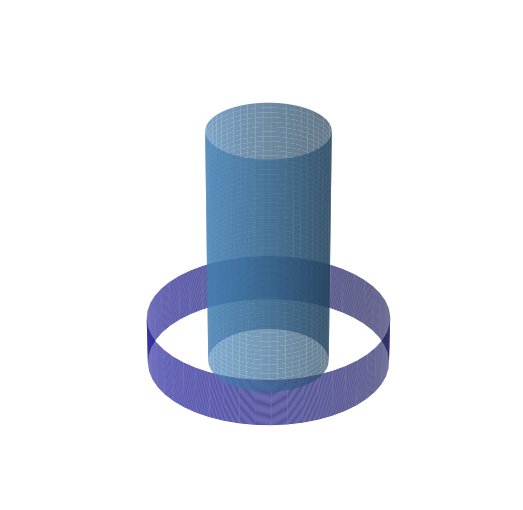

```python
f = plt.figure(figsize=(9,9))
ax = f.add_subplot(111, projection='3d')

def create_cylinder(center_x,center_y,radius,height):
    z = numpy.linspace(0, height, 50)
    theta = numpy.linspace(0, 2*numpy.pi, 50)
    theta_grid, z_grid = numpy.meshgrid(theta, z)
    x_grid = radius * numpy.cos(theta_grid) + center_x
    y_grid = radius * numpy.sin(theta_grid) + center_y
    return x_grid,y_grid,z_grid

Xc,Yc,Zc = create_cylinder(0,0,0.2,0.6)
ax.plot_surface(Xc, Yc, Zc, alpha=0.7, color='darkblue')

Xc2,Yc2,Zc2 = create_cylinder(0,0,0.1,3.0)
ax.plot_surface(Xc2, Yc2, Zc2, alpha=0.7, color='steelblue')

plt.axis('off');
```

$V_1 = \pi * r_1^2 * h_1; \ h_2 = 5 * h_1; \ r_2 = \large{\frac {r_1}{2}}$

$V_2 = \pi * r_2^2 * h_2 = \pi * \large{(\frac {r_1}{2})^2}$ $* 5 * h_1 = V_1 * \large{\frac {5}{4}}$

$V_2 = 24 * \large{\frac {5}{4}} = 30$

### Ответ / Answer: 30

```python
answer_dictionary[8]=str(int(24/4*5))
```

[figure not shown]

### Задание 9 / Task 9

Найдите значение выражения

Find the value of the expression

$log_6{126} - log_{6}{3.5}$.

```python
%%latex
$log_6{126} - log_6{3.5} = \large{log_6{\frac{126}{3.5}}} =$
$= log_6{36} = log_6{6^2} = 2$
```

$log_6{126} - log_6{3.5} = \large{log_6{\frac{126}{3.5}}} =$ $= log_6{36} = log_6{6^2} = 2$

### Ответ / Answer: 2

```python
answer_dictionary[9]=str(int(math.log(126/3.5,6)))
```

[figure not shown]

### Задание 10 / Task 10

Для одного из предприятий-монополистов зависимость объема спроса на продукцию $q$ (единиц в месяц) от её цены $p$ (тыс.руб.) задается формулой: $q = 100 - 10 * p$.

Определите максимальный уровень цены $p$ (в тыс.руб.), при котором значение выручки предприятия за месяц $r = q * p$ составит не менее 210 тыс.руб.

For one of the monopoly enterprises, the dependence of the volume of demand for $q$ production (units per month) on its price $p$ (thousand rubles) is given by the formula: $q = 100 - 10 * p$.

Determine the maximum level of the price $p$ (in thousands of rubles), at which the value of the company's revenue for the month $r = q * p$ will be at least 210 thousand rubles.

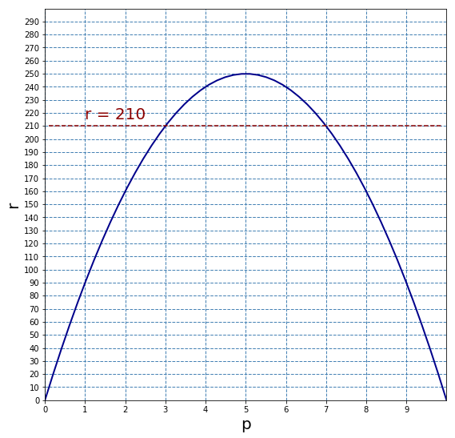

```python
f = plt.figure(figsize=(9,9))
ax = f.add_subplot(1,1,1)
ax.grid(c='steelblue', ls='--', lw=1)

plt.xlim(0,10)
plt.ylim(0,300)
plt.xticks(numpy.arange(0, 10, step=1))
plt.yticks(numpy.arange(0, 300, step=10))
plt.xlabel('p', fontsize=20)
plt.ylabel('r', fontsize=20)

def r(p): return (100 - 10 * p) * p

P = numpy.linspace(0,10)
R = [r(p) for p in P]
ax.plot(P, R, c='darkblue', lw=2)
ax.axhline(210, 0.01, 0.99, c='darkred',ls='--')
plt.text(1,215,'r = 210', color='darkred', fontsize=20);
```

Представим выручку как функцию одной переменной - цены.

Let's represent the revenue as a function of one variable - the price.

```python
%%latex
$r = q * p = (100 - 10 * p) * p = 100 * p - 10 * p^2 \\
100 * p - 10 p^2 \geq 210 \\
p^2 - 10 * p + 21 \leq 0 \\
(p - 3) * (p - 7) \leq 0 \\
3 \leq p \leq 7 \implies \large{p_{max} = 7}$
```

$r = q * p = (100 - 10 * p) * p = 100 * p - 10 * p^2 \\ 100 * p - 10 p^2 \geq 210 \\ p^2 - 10 * p + 21 \leq 0 \\ (p - 3) * (p - 7) \leq 0 \\ 3 \leq p \leq 7 \implies \large{p_{max} = 7}$

### Ответ / Answer: 7

```python
# check the decision method
p = Symbol('p')
r = (100 - 10 * p) * p - 210
```

```python
expand(r)
```

$$- 10 p^{2} + 100 p - 210$$

```python
solve(r,p)
```

$$\left [ 3, \quad 7\right ]$$

```python
max(solve(r,p))
```

$$7$$

```python
answer_dictionary[10]=str(max(solve(r,p)))
```

[figure not shown]

### Задание 11 / Task 11

Первая труба наполняет бак объёмом 600 литров, а вторая труба - бак объёмом 900 литров. Известно, что одна из труб пропускает в минуту на 3 л воды больше, чем другая.

Сколько литров воды в минуту пропускает вторая труба, если баки были наполнены за одно и то же время?

The first pipe fills the tank with a volume of 600 liters, and the second pipe - a tank with a volume of 900 liters. It is known that one of the pipes passes per minute to 3 liters of water more than the other.

How many liters of water per minute does the second pipe let through if the tanks were filled at the same time?

Пусть v литров в минуту пропускает вторая труба, тогда первая - (v - 3) литров в минуту.

Известно, что время заполнения баков - одинаковое:

Let us denote v liters per minute the ability to pass for the second pipe, then for the first one - (v - 3) liters per minute.

It is known that the filling time of tanks is the same:

$\large{\frac{600}{v - 3} = \frac{900}{v}} \\ 600 * v = 900 * (v - 3) \\ 300 * v = 2700 \\ v = 9$

### Ответ / Answer: 9

```python
# check the decision method
v = Symbol('v')
t = 600 / (v - 3) - 900 / v
```

```python
expand(t)
```

$$\frac{600}{v - 3} - \frac{900}{v}$$

```python
solve(t,v)
```

$$\left [ 9\right ]$$

```python
answer_dictionary[11]=str(max(solve(t,v)))
```

[figure not shown]

### Задание 12 / Task 12

Найдите точку максимума функции $y = (2 * x - 3) * cos \ x - 2 * sin \ x + 20$, принадлежащую промежутку $\large{\bigg(0; \frac{\pi}{2}\bigg)}$.

Find the argument of the maximum value for the function $y = (2 * x - 3) * cos \ x - 2 * sin \ x + 20$ belonging to the interval $\large {\bigg (0; \frac {\pi} {2} \bigg )}$.

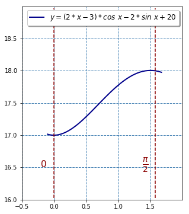

```python
f = plt.figure(figsize=(6,6))
ax = f.add_subplot(1, 1, 1, aspect=1)
ax.grid(c='steelblue', ls='--', lw=1)

def f(x):
    return (2 * x - 3) * math.cos(x) - 2 * math.sin(x) + 20

x = numpy.linspace(-0.1,math.pi/2+0.1)
y = [f(el) for el in x]
ax.plot(x, y, c='darkblue', lw=2,
        label=r'$y = (2 * x - 3) * cos \ x - 2 * sin \ x + 20$')

ax.axvline(0, 0.01, 0.99, c='darkred',ls='--')
ax.axvline(math.pi/2, 0.01, 0.99, c='darkred',ls='--')
plt.text(-0.2,16.5,'0', color='darkred', fontsize=15)
plt.text(math.pi/2-0.2,16.5,r'$\frac{\pi}{2}$',
         color='darkred', fontsize=20)

plt.xlim(-0.5,2)
plt.ylim(16,19)
plt.xticks(numpy.arange(-0.5,2, step=0.5))
plt.yticks(numpy.arange(16,19, step=0.5))
plt.legend(fontsize=12, shadow=True);
```

```python
x = Symbol('x')
y = (2 * x - 3) * cos(x) - 2 * sin(x) + 20
```

Наибольшего и наименьшего значений непрерывная функция может достигать:

- на концах отрезка,
- в стационарных или критических точках (производная равна 0 или не существует).

The largest and smallest values can be for the continuous function:

- at the ends of the segment,
- at stationary or critical points (the derivative is 0 or does not exist).

```python
# y(0)
y.subs({x:0})
```

$$17$$

```python
# y(π/2)
y.subs({x:pi/2})
```

$$18$$

```python
# y(x)
expand(y)
```

$$2 x \cos{\left (x \right )} - 2 \sin{\left (x \right )} - 3 \cos{\left (x \right )} + 20$$

```python
# производная | the first derivative
diff(y,x)
```

$$- \left(2 x - 3\right) \sin{\left (x \right )}$$

```python
# производная равна нулю: ∣ the derivative is 0
solve(diff(y,x),x)
```

$$\left [ 0, \quad \frac{3}{2}, \quad \pi\right ]$$

```python
# вторая производная / the second derivative
diff(diff(y,x),x)
```

$$- \left(2 x - 3\right) \cos{\left (x \right )} - 2 \sin{\left (x \right )}$$

```python
# y''(0) > 0 => min
diff(diff(y,x),x).subs({x:0})
```

$$3$$

```python
# y''(1.5) < 0 => max
diff(diff(y,x),x).subs({x:1.5})
```

$$-1.99498997320811$$

```python
# y(1.5) > y(π/2) > y(0)
y.subs({x:1.5})
```

$$18.0050100267919$$

### Ответ / Answer: 1,5

```python
answer_dictionary[12]=str(1.5)
```

## Часть 2 Part 2

[figure not shown]

### Задание 13 / Task 13

a) Найдите корень уравнения:

a) Find the root of the equation:

$tg^2 x + 5 * tg \ x + 6 = 0$.

б) Найдите все корни этого уравнения, принадлежащие промежутку

b) Find all the roots of this equation that belong to the interval

$\large{[-2 * \pi; \frac{-\pi}{2}]}$.

a)

$tg^2 x + 5 * tg \ x + 6 = 0 \\ (tg \ x + 2) * (tg \ x + 3) = 0 \\ tg \ x = - 2 \lor tg \ x = - 2 \\ x = -arctg \ 2 + \pi * n \lor x = -arctg \ 3 + \pi * k, \\ n, k \in \mathbb{Z}$

б)

$x = -arctg \ 2 - \pi \lor x = -arctg \ 3 - \pi$

### Ответ / Answer:

$ a) -arctg \ 2 + \pi * n, -arctg \ 3 + \pi * k; n, k \in \mathbb{Z}; б) -arctg \ 2 - \pi, -arctg \ 3 - \pi$

```python
-2*math.pi, -math.atan(3)-math.pi, -math.atan(2)-math.pi, -math.pi/2
```

$$\left ( -6.283185307179586, \quad -4.3906384259880475, \quad -4.2487413713838835, \quad -1.5707963267948966\right )$$

```python
# check the decision method
x = Symbol('x')
y = tan(x) ** 2 + 5 * tan(x) + 6
```

```python
solve(y,x)
```

$$\left [ - \operatorname{atan}{\left (2 \right )}, \quad - \operatorname{atan}{\left (3 \right )}\right ]$$

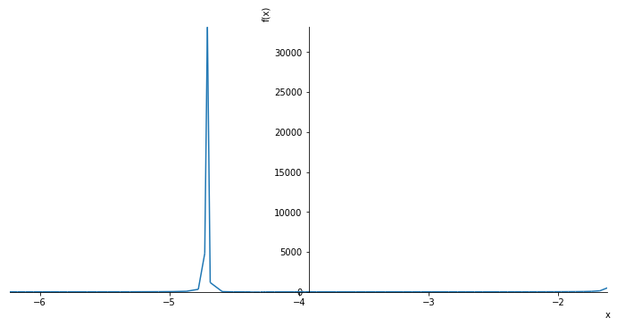

```python
plt.rcParams['figure.figsize'] = 12, 6
plot(y,(x,-2*pi+0.05,-pi/2-0.05));
```

```python
answer_dictionary[13]=str('a)−arctg2+π∗n,−arctg3+π∗k; n,k∈ℤ; б)−arctg2−π,−arctg3−π')
```

[figure not shown]

### Задание 14 / Task 14

Диаметр окружности основания цилиндра равен 26, образующая цилиндра равна 21.

Плоскость пересекает его основания по хордам длины 24 и 10.

Расстояния между этими хордами равно $7 \sqrt{10}$.

а) Постройте прямую пересечения этой плоскости с плоскостью, проходящей через диаметры оснований, перпендикулярные к этим хордам.

б) Найдите угол между этой плоскостью и плоскостью основания цилиндра.

The diameter of the circle base of the cylinder is 26, the height of the cylinder is 21.

The plane crosses its bases along the chords of lengths 24 and 10.

The distance between these chords is $7 \sqrt {10}$.

a) Construct the line of intersection of this plane with the plane passing through the diameters of the bases, perpendicular to these chords.

b) Find the angle between this plane and the plane of the base of the cylinder.

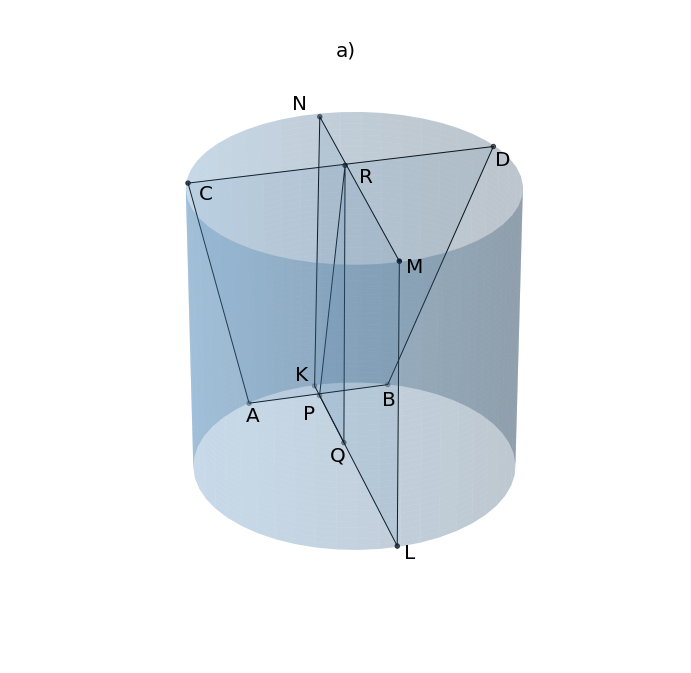

```python
f = plt.figure(figsize=(12,12))
ax = f.add_subplot(111, projection='3d')

Xc,Yc,Zc = create_cylinder(0,0,1,4)
ax.plot_surface(Xc, Yc, Zc, alpha=0.3, color='steelblue')

letter_xyz = numpy.array([[-0.85,0.1,0],[-0.2,0.7,0],[-0.7,-0.62,4],[0.6,0.65,4],
                          [-0.85,0.7,0],[0.8,-0.8,0],[0.8,-0.8,4],[-0.85,0.7,4],
                          [-0.55,0.3,0],[-0.15,-0.05,0],[0,0.05,4]])
letter_symbols = numpy.array(['A','B','C','D',
                              'K','L','M','N',
                              'P','Q','R'])

for i in range(len(letter_xyz)):
    ax.text(letter_xyz[i][0], letter_xyz[i][1], letter_xyz[i][2],
            letter_symbols[i], color='black', fontsize=20)

v = numpy.array([[0.7,-0.7,0], [-0.7,0.7,0], [0.7,-0.7,4], [-0.65,0.7,4],
                 [-0.3,0.95,0], [-0.95,0.3,0], [-0.87,-0.47,4], [0.47,0.87,4],
                 [-0.61,0.61,0], [-0.18,0.2,4], [-0.18,0.18,0]])
ax.scatter3D(v[:, 0], v[:, 1], v[:, 2], color='black')

verts = [ [v[0],v[2],v[3],v[1]], [v[4],v[5],v[6],v[7]], [v[8],v[9],v[10]] ]

lines = Poly3DCollection(verts, lw=1, alpha=0.1,
                         edgecolors='black', facecolor='none')
lines.set_facecolor('steelblue')
ax.add_collection3d(lines)

plt.title('a)', fontsize=20);
plt.axis('off');
```

б)

1)

По построению $NM = KL = 26$ - диаметры оснований; $AB \bot KL, CD \bot NM$.

Плоскости $ABC$ и $NMK$ пересекают каждое из оснований цилиндра по перпендикулярным прямым $\implies ABC \bot NMK$.

$ABC \cap NMK = PR \implies PR \bot AB, PR \bot CD, PR \bot KL, PR \bot MN$.

Опустим перпендикуляр PQ на плоскость основания ABL. По теореме о трех перпендикулярах $PQ \bot AB \implies$ необходимо найти $\angle RPQ$.

By drawing, $NM = KL = 26$ are the diameters of the bases; $AB \bot KL, CD \bot NM$.

The planes $ABC$ and $NMK$ intersect each of the cylinder bases along the perpendicular lines $\implies ABC \bot NMK$.

$ABC \cap NMK = PR \implies PR \bot AB, PR \bot CD, PR \bot KL, PR \bot MN$.

Let's lower the perpendicular PQ to the plane of the base ABL. By the theorem on three perpendiculars $PQ \bot AB \implies$ it is necessary to find $\angle RPQ$.

2)

$PQ \bot KM \implies \sin (\angle QPR) = \large{\frac{RQ}{PQ}}$ $\implies \sin (\angle QPR) =$ $\large{\frac{21}{7 \sqrt{10}} = \frac{3}{\sqrt{10}}}$

$\implies \cos (\angle QPR) = 1 - \sin^2 (\angle QPR) = \large{\frac{1}{\sqrt{10}}}$ $\implies \tan (\angle QPR) =$ $\large{\frac{\sin (\angle QPR)}{\cos (\angle QPR)}} = 3$

### Ответ / Answer: $б) \arctan{3}$

```python
answer_dictionary[14]=str('б) arctg3')
```

[figure not shown]

### Задание 15 / Task 15

Решите неравенство:

Solve the inequality:

$\large{\log_{x + 1} {(x - 1)} * \log_{x + 1} {(x + 2)} \leq 0}$

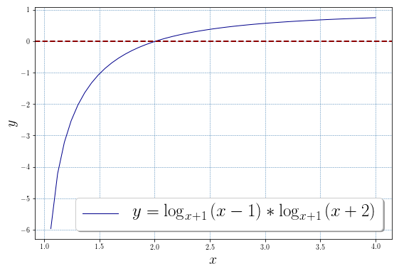

```python
import matplotlib
from __future__ import unicode_literals

matplotlib.rcParams['text.usetex'] = True
matplotlib.rcParams['text.latex.unicode'] = True
plt.figure(figsize=(9,6))

x = numpy.linspace(1,4)
y = [log(el-1,el+1)*log(el+2,el+1) for el in x]
plt.plot(x, y, c='darkblue', lw=1,
         label=r'$y = \log_{x + 1} {(x - 1)} * \log_{x + 1} {(x + 2)}$')
plt.axhline(0, c='darkred', ls='--', lw=2)

plt.grid(c='steelblue', ls='--', lw=0.5)
plt.xlabel(r'$x$', fontsize=20)
plt.ylabel(r'$y$', fontsize=20)
plt.legend(fontsize=25, shadow=True);
```

1) Область допустимых значений: / Range of admissible values:

$\begin{cases} x + 1 > 0 \\ x + 1 \neq 1 \\ x - 1 > 0 \\ x + 2 > 0\end{cases} \iff \ \begin{cases} x > -1 \\ x \neq 0 \\ x > 1 \\ x > -2\end{cases} \iff \ x > 1$

2) Преобразования неравенства с использованием метода декомпозиции: / Inequality transformations using the decomposition method:

$\log_{f(x)} {g(x)} * \log_{f(x)} {h(x)} \leq 0 \iff (f(x) - 1) * (g(x) - 1) * (f(x) - 1) * (h(x) - 1) \leq 0 \iff \\ \iff (f(x) - 1)^2 * (g(x) - 1) * (h(x) - 1) \leq 0$

$(x + 1 - 1)^2 * (x - 1 - 1) * (x + 2 - 1) \leq 0 \iff x^2 * (x - 2) * (x + 1) \leq 0 \iff -1 \leq x \leq 2$

3) $1) \cap 2) \implies x > 1 \land -1 \leq x \leq 2 \iff 1 < x \leq 2$

### Ответ / Answer: $x \in (1;2]$

```python
answer_dictionary[15]='x∈(1;2]'
```

[figure not shown]

### Задание 16 / Task 16

✒ `В пособии опечатка. Пункт б) сформулирован неверно.`

Окружности радиусов 2 и 4 касаются в точке B.

Через точку B проведена прямая, пересекающая второй раз меньшую окружность в точке A, а большую - в точке C.

а) Докажите, что BC = 2 * AB.

б) Найдите BC, если AC = $3 \sqrt{2}$.

Circles of radiuses 2 and 4 touch at the point B.

Through point B, a straight line is drawn.

It intersects the smaller circle at the point A the second time, and the larger one - at the point C.

a) Prove that BC = 2 * AB.

b) Find BC if AC = $3 \sqrt{2}$.

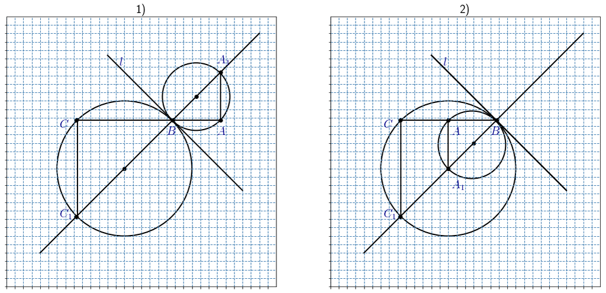

```python
f = plt.figure(figsize=(18,9))
ax = f.add_subplot(1, 2, 1, aspect=1)
ax.grid(c='steelblue', ls='--', lw=1)

plt.xlim(-9,7)
plt.ylim(-9,7)
plt.xticks(numpy.arange(-9, 7, step=0.5), visible=False)
plt.yticks(numpy.arange(-9, 7, step=0.5), visible=False)

letter_xy = numpy.array([[-5.8,-5],[-5.8,0.4],[0.5,0],
                         [3.5,4.1],[3.5,0],[-2.3,4.1]])
letter_symbols = numpy.array([r'$C_1$',r'$C$',r'$B$',
                              r'$A_1$',r'$A$',r'$l$'])

for i in range(len(letter_xy)):
    ax.text(letter_xy[i][0], letter_xy[i][1],
            letter_symbols[i], color='darkblue', fontsize=20)

ax.scatter([-4.85,-4.85,-2,0.85,2.25,3.7,3.7],
           [-4.85,0.85,-2,0.85,2.25,3.7,0.85], c='black')
ax.plot([-7,6],[-7,6], c='black', lw=2)
plt.axhline(0.85,0.26,0.79, c='black', lw=2)
plt.axvline(-4.8,0.26,0.62, c='black', lw=2)
plt.axvline(3.7,0.61,0.79, c='black', lw=2)
ax.plot([-3,5],[4.7,-3.3], c='black', lw=2)

circle = pat.Circle((-2, -2), 4, lw=2,
                edgecolor='black', facecolor='none')
circle2 = pat.Circle((2.25, 2.25), 2, lw=2,
                edgecolor='black', facecolor='none')
ax.add_artist(circle)
ax.add_artist(circle2)
plt.title('1)', fontsize=20)

ax2 = f.add_subplot(1, 2, 2, aspect=1)
ax2.grid(c='steelblue', ls='--', lw=1)
plt.xlim(-9,7)
plt.ylim(-9,7)
plt.xticks(numpy.arange(-9, 7, step=0.5), visible=False)
plt.yticks(numpy.arange(-9, 7, step=0.5), visible=False)

letter_xy2 = numpy.array([[-5.8,-5],[-5.8,0.4],[0.5,0],
                          [-1.8,-3.3],[-1.8,0],[-2.3,4.1]])
letter_symbols2 = numpy.array([r'$C_1$',r'$C$',r'$B$',
                               r'$A_1$',r'$A$',r'$l$'])

for i in range(len(letter_xy2)):
    ax2.text(letter_xy2[i][0], letter_xy2[i][1],
             letter_symbols2[i], color='darkblue', fontsize=20)

ax2.scatter([-4.85,-4.85,-2,0.85,-0.5,-2],
           [-4.85,0.85,-2,0.85,-0.5,0.85], c='black')
ax2.plot([-7,6],[-7,6], c='black', lw=2)
plt.axhline(0.85,0.26,0.61, c='black', lw=2)
plt.axvline(-4.8,0.26,0.61, c='black', lw=2)
plt.axvline(-2,0.43,0.61, c='black', lw=2)
ax2.plot([-3,5],[4.7,-3.3], c='black', lw=2)


circle3 = pat.Circle((-2, -2), 4, lw=2,
                edgecolor='black', facecolor='none')
circle4 = pat.Circle((-0.6, -0.6), 2, lw=2,
                edgecolor='black', facecolor='none')
ax2.add_artist(circle3)
ax2.add_artist(circle4)

ax2.plot([-3,5],[4.7,-3.3], c='black', lw=2)

plt.title('2)', fontsize=20);
```

1) *Внешнее касание. / External touch.*

a)

Через точку $B$ и центры окружностей проведем прямую, перпендикулярную общей касательной $l$ в точке $B$ и пересекающую окружности в точках $A_1$ и $C_1$ соответственно. При этом отрезки $A_1B = 2 * 2 = 4$ и $C_1B = 2 * 4 = 8$ - диаметры окружностей.

Through the point $B$ and the centers of circles draw a line perpendicular to the common tangent $l$ at the point $B$ and intersect the circles at the points $A_1$ and $C_1$, respectively. In this case, the segments $A_1B = 2 * 2 = 4$ and $C_1B = 2 * 4 = 8$ are the diameters of the circles.

$\triangle A_1AB$ и $\triangle BCC_1$ - прямоугольные, т.к. $\angle A_1AB$ и $\angle C_1CB$ опираются на диаметр. $\angle A_1BA$ и $\angle C_1BC$ равны как вертикальные. Значит, $\triangle A_1AB$ и $\triangle BCC_1$ - подобные.

$\triangle A_1AB$ и $\triangle BCC_1$ are rectangular, because $\angle A_1AB$ и $\angle C_1CB$ are supported by the diameter. $\angle A_1BA$ and $\angle C_1BC$ are equal as vertical. Hence, $\triangle A_1AB$ and $\triangle BCC_1$ are similar.

Коэффициент подобия равен / The similarity coefficient is

$\large{\frac{C_1B}{A_1B} = \frac{8}{4}}$ $= 2 \implies BC = 2 * AB$

б) $AC = AB + BC = AB + 2 * AB = 3 \sqrt{2} \implies AB = \sqrt{2} \ \& \ BC = 2 \sqrt{2}$

2) *Внутреннее касание. / Internal touch.*

а) Подобие треугольников рассматривается аналогично. / The similarity of triangles is treated the same.

б) $AC = BC - AB = 2 * AB - AB = AB = 3 \sqrt{2} \implies BC = 6 \sqrt{2}$

### Ответ / Answer: $б) \ 2 \sqrt{2} \ \lor \ 6 \sqrt{2}$

```python
answer_dictionary[16]=str('б) 2√2 ∨ 6√2')
```

[figure not shown]

### Задание 17 / Task 17

31 декабря 2014 года Леонид взял в банке 1 млн. рублей в кредит. Схема выплаты кредита следующая - 31 декабря каждого следующего года банк начисляет проценты на оставшуюся сумму долга (то есть увеличивает долг на a%), затем Леонид переводит очередной транш. Леонид выплатил кредит за два транша, переведя в первый раз 700 тыс. рублей, во второй - 440 тыс. рублей.

Под какой процент банк выдал кредит Леониду?

December 31, 2014, Leonid took in the bank 1 million rubles on credit. A loan repayment scheme is the following - on December 31 of each following year, the bank accrues interest on the remaining amount of debt (that is, increases the debt by a%), then Leonid transfers the next tranche. Leonid paid the loan for two tranches, transferring for the first time 700 thousand rubles, in the second one - 440 thousand rubles.

Under what percentage of the bank gave a loan to Leonid?

Пусть k - процент кредита, тогда 31 декабря 2015 года сумма долга составила:

Let k be the loan interest, then on December 31, 2015, the amount of debt was:

$1000000 * (1 + 0.01 * k) = 1000000 + 10000 * k$.

После перевода первого транша долг уменьшился:

After the transfer of the first tranche, the debt decreased:

$1000000 + 10000 * k - 700000 = 300000 + 10000 * k$.

31 декабря 2016 года проценты начислены снова, сумма долга стала равной:

December 31, 2016, the loan interest accrued again, the amount of debt became equal to:

$(300000 + 10000 * k) * (1 + 0.01 * k) = 300000 + 13000 * k + 100 * k^2$.

После этого переводился второй транш, долг уменьшился до нуля:

After that, the second tranche was transferred, the debt decreased to zero:

$300000 + 13000 * k + 100 * k^2 - 440000 = 100 * k^2 + 13000 * k- 140000 = 0$.

$k^2 + 130 * k - 1400 = 0 \\ D = 130^2 - 4 * (-1400) = 22500 \\ k = \frac{-130 + 150}{2} = 10 \ (k > 0!)$

### Ответ / Answer: 10

```python
# check the decision method
k = Symbol('k')
c = (1000000 * (1 + 0.01 * k) - 700000) * (1 + 0.01 * k) - 440000
```

```python
expand(c)
```

$$100.0 k^{2} + 13000.0 k - 140000$$

```python
solve(c,k)
```

$$\left [ -140.0, \quad 10.0\right ]$$

```python
answer_dictionary[17]=str(10)
```

[figure not shown]

### Задание 18 / Task 18

Найдите все значения параметра a, при каждом из которых модуль разности корней уравнения

$x^2 - 6 * x + 12 + a^2 - 4 * a = 0$

принимает наибольшие значения.

Find all the values of the parameter a, for each of which the modulus of the root difference of the equation

$x^2 - 6 * x + 12 + a^2 - 4 * a = 0$

takes the greatest values.

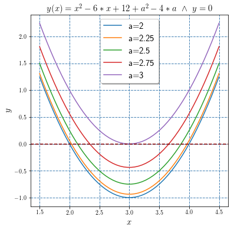

```python
def F(x,a): return x ** 2 - 6 * x + 12 + a **2 - 4 * a
X = numpy.linspace(1.5, 4.5)

plt.figure(figsize=(6,6))
for a in [2, 2.25, 2.5, 2.75, 3]:
    plt.plot(X, [F(x,a) for x in X], label='a='+str(a))

plt.axhline(0, c='darkred', ls='--')
plt.legend(shadow=True, loc=9, fontsize=15)
plt.xlabel(r'$x$', fontsize=15)
plt.ylabel(r'$y$', fontsize=15)
plt.title(r'$y(x) = x^2 - 6 * x + 12 + a^2 - 4 * a \ \land \ y = 0$', fontsize=15)
plt.grid(c='steelblue', ls='--', lw=1);
```

$x^2 - 6 * x + 12 + a^2 - 4 * a = 0$

$x_1 - x_2 = \large{\frac{6 + \sqrt{6^2 - 4 * (12 + a^2 - 4 * a)}}{2} - \frac{6 - \sqrt{6^2 - 4 * (12 + a^2 - 4 * a)}}{2}}$

$x_1 - x_2 = \sqrt{6^2 - 4 * (12 + a^2 - 4 * a)}$

$x_1 - x_2 = 2 * \sqrt{- a^2 + 4 * a - 3}$

$x_1 - x_2 - max \iff f(a) = - a^2 + 4 * a - 3 - max$

$f'(a) = -2 * a + 4; \ f'(2) = 0; \ f''(a) = -2 \implies f(a) - max \iff a = 2$

### Ответ / Answer: 2

```python
answer_dictionary[18]='a=2'
```

[figure not shown]

### Задание 19 / Task 19

Последовательность $a_1, a_2, ..., a_n, ...$ состоит из натуральных чисел, причём $a_{n+2} = a_{n+1} + a_n$ при всех натуральных n.

а) Может ли выполняться равенство $4 * a_5 = 7 * a_4 \ (1)$?

б) Может ли выполняться равенство $5 * a_5 = 7 * a_4 \ (2)$?

в) При каком наибольшем натуральном n может выполняться равенство $6 * n * a_{n+1} = (n^2 + 24) * a_n \ (3)$?

The sequence $a_1, a_2, ..., a_n, ...$ consists of positive integers, and $a_{n + 2} = a_{n + 1} + a_n$ for all positive integers n.

a) Can the equality $4 * a_5 = 7 * a_4 \ (1)$ be fulfilled?

б) Can the equality $5 * a_5 = 7 * a_4 \ (2)$ be fulfilled?

в) For what maximum natural number n can the equality $6 * n * a_{n + 1} = (n^2 + 24) * a_n \ (3)$ be satisfied?

a)

$4 * a_5 = 7 * a_4 \\ 4 * (a_4 + a_3) = 7 * a_4 \\ 3 * a_4 = 4 * a_3 \\ 3 * (a_3 + a_2) = 4 * a_3 \\ a_3 = 3 * a_2 \\ a_2 + a_1 = 3 * a_2 \\ a_1 = 2 * a_2$

$(1)$ выполняется для всех натуральных последовательностей указанного вида, если $a_1 = 2 * a_2$.

$(1)$ holds for all natural sequences of the indicated type if $a_1 = 2 * a_2$.

б)

$5 * a_5 = 7 * a_4 5 * (a_4 + a_3) = 7 * a_4 \\ 2 * a_4 = 5 * a_3 \\ 2 * (a_3 + a_2) = 5 * a_3 \\ 3 * a_3 = 2 * a_2 \\ 3 * (a_2 + a_1) = 2 * a_2 \\ a_2 = -3 * a_1$

$(2)$ не выполняется ни для одной натуральной последовательности указанного вида, т.к. $a_1, a_2$ не могут быть отрицательными.

$ (2) $ is not satisfied for any natural sequence of the indicated type, because $ a_1, a_2 $ can not be negative.

в)

[output not shown]

### Ответ / Answer: a) да; б) нет; в) n=5

```python
answer_dictionary[19]='a)да; б)нет; в)при n=5'
```

## Ответы / Answers

```python
answer_dictionary
```

```
{1: '245',
 2: '4 000 000',
 3: '3',
 4: '0.33',
 5: '45',
 6: '34',
 7: '4',
 8: '30',
 9: '2',
 10: '7',
 11: '9',
 12: '1.5',
 13: 'a)−arctg2+π∗n,−arctg3+π∗k; n,k∈ℤ; б)−arctg2−π,−arctg3−π',
 14: 'б) arctg3',
 15: 'x∈(1;2]',
 16: 'б) 2√2 ∨ 6√2',
 17: '10',
 18: 'a=2',
 19: 'a)да; б)нет; в)при n=5'}
```

[figure not shown]